# COVID19_Lineage_assignment_changes_through_time_report

Julie Chih-yu Chen

April 05, 2022

The script in this markdown is used to generate the Sankey visualization of changes in Pangolin lineage assignment at any point in specificied timepoints, and report top changes in counts and proportions of lineages. It is compatible with Pangolin v3.0 and v4.0. The pairs of changes are also saved in an excel spreadsheet for reference.

### loading pangolin prediction output:

lineage_report.csv in each of the folder under “inputDir” The pangolin, pangolearn and pango (designation) versions as well as constellation and scorpio versions are printed when available.

```
##      RunName      pangolin version          scorpio constellation pangoLEARN
## [1,] "2021_11_08" "3.1.16" "PLEARN-v1.2.88" ""      ""            "2021-10-18"
## [2,] "2021_11_09" "3.1.16" "PLEARN-v1.2.88" ""      ""            "2021-10-18"
## [3,] "2021_11_10" "3.1.16" "PLEARN-v1.2.91" ""      ""            "2021-11-04"
## [4,] "2021_11_15" "3.1.16" "PLEARN-v1.2.91" ""      ""            "2021-11-04"
## [5,] "2021_11_17" "3.1.16" "PLEARN-v1.2.93" ""      ""            "2021-11-09"
```

```
## [1] "Total unique number of lineages in these runs: 229"
```

```
## starting httpd help server ... done
```

### Getting the overall counts and percentages of reassignment, consecutive time point comparison

```
## [1] 0
## [1] 407
## [1] 0
## [1] 63
```

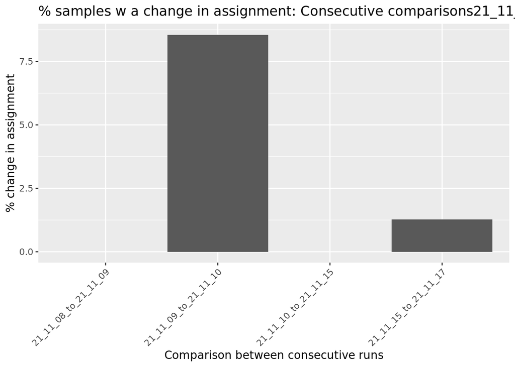

### Examining changes per lineage with counts versus percentage

One way to flag lineages with less steady assignment in question: - A bionimial test was conducted per lineage with the probability of change set to 10%, and subsequently the Bonferonni multiple hypothesis testing correction was followed. - The scatter plot highlights the percent and count changes per lineage, represented as points. These points are colored by its significance in changes. The color legend reflects the level of significance in change from binomial tests: -log10(Bonferroni-corrected p). Top 10 significant lineages or those with > 100 changes in counts were labeled in the figure.

```
## [1] "No significant changes 21_11_08_to_21_11_09"
```

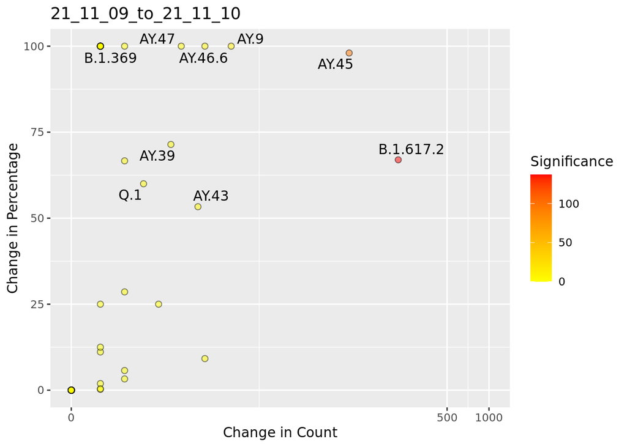

```
## [1] "10 Significant changes 21_11_09_to_21_11_10"
##           count   percent          adjp
## B.1.617.2   223  66.96697 1.020316e-137
## AY.45        99  98.01980  1.639840e-95
## AY.9         14 100.00000  2.000000e-14
## AY.46.6       9 100.00000  2.000000e-09
## AY.47         6 100.00000  4.000000e-06
## AY.43         8  53.33333  1.344996e-04
## AY.39         5  71.42857  7.060000e-04
## Q.1           3  60.00000  3.424000e-02
## B.1.369       2 100.00000  4.000000e-02
## [1] "No significant changes 21_11_10_to_21_11_15"
```

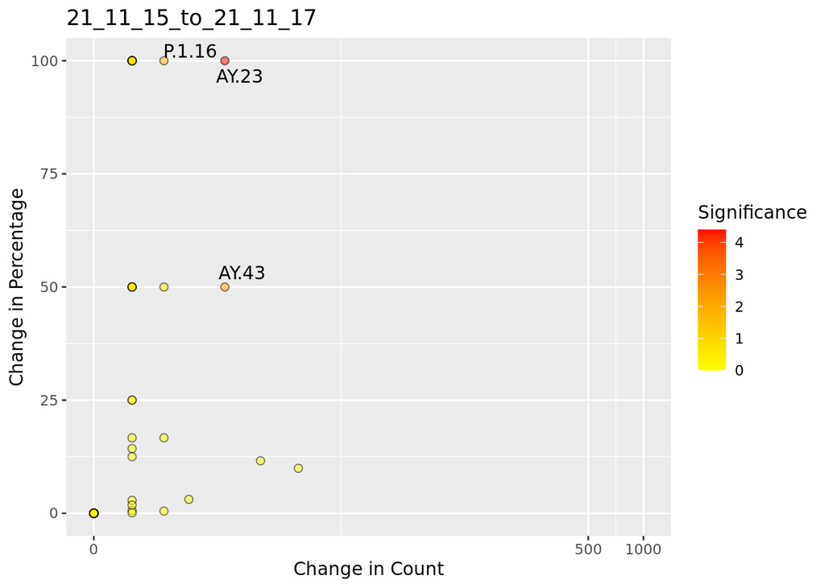

```
## [1] "10 Significant changes 21_11_15_to_21_11_17"
##        count percent       adjp
## AY.23      5     100 0.00004000
## AY.43      5      50 0.00653975
## P.1.16     2     100 0.02000000
```

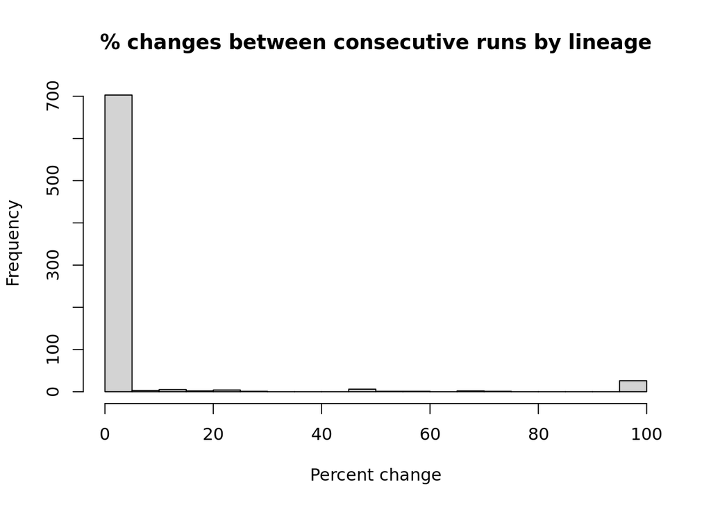

### Examining pairs of lineage changes between any two timepoints

If there is any change in lineage classification between two timepoints, visualize the counts of lineage change pairs in a barplot and the change states in a pie chart. The change states simply note if the new lineage is a child/grandchild/descendant of the original lineage (child), if the new lineage is a parent of the original lineage (parent), if the new lineage share the same direct parent with the original one (sibling), if one of the classification was “Unassigned” from pangolin v4 or “None” from pangolin v3 (Unassigned), and if it’s none of the above (other).

```
## [1] "The heirarchy version extracted by Adrian:"
## [1] "commit ca5b1b15e4d51f7f5f95939ea9ba85d634470925;Author: Rachel Colquhoun <rachel.colquhoun@ed.ac.uk>;Date:   Tue Mar 15 04:33:22 2022 +0000"
## [1] "No changes for 21_11_08_to_21_11_09"
## [1] "The following plot had to be reduced to top 50 pairs only."
```

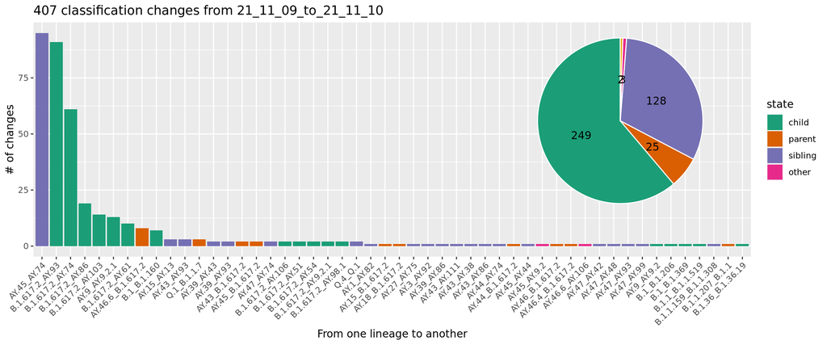

```
## [1] "No changes for 21_11_10_to_21_11_15"
```

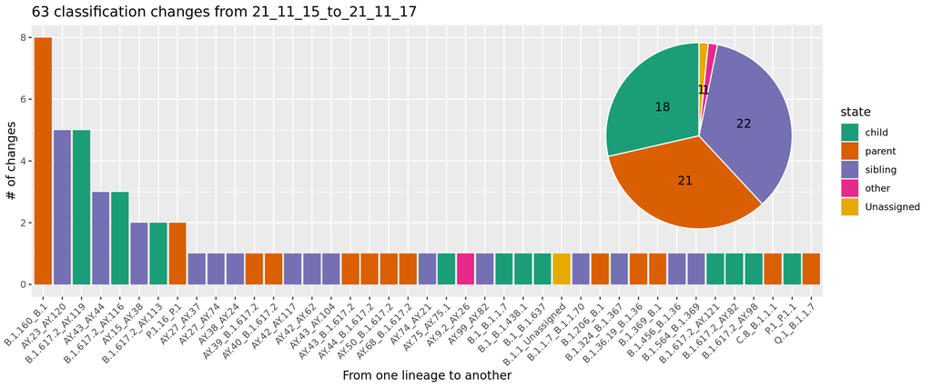